# Evaluatie soortenmeetnetten 2018

## 3.3 Verkenning van de ingevoerde aantallen

### 3.3.1 Transecttellingen

#### 3.3.1.1 Verdeling getelde aantallen per bezoek

Onderstaande figuren tonen de verdeling van de getelde aantallen per bezoek.

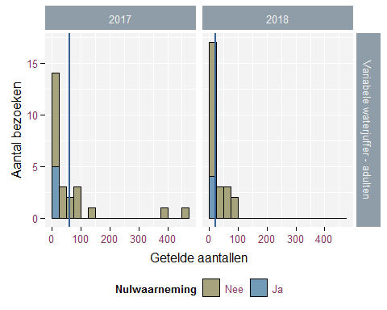

Figuur 3.2: Verdeling van totaal getelde aantallen per bezoek en het gemiddelde van de getelde aantallen (verticale lijn) - Variabele waterjuffer - adulten

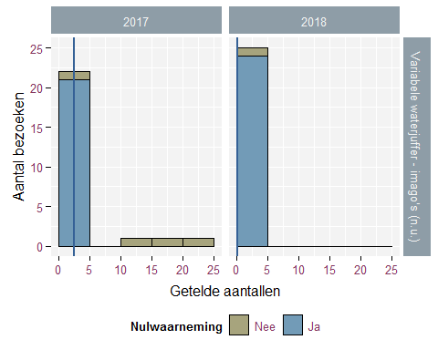

Figuur 3.2: Verdeling van totaal getelde aantallen per bezoek en het gemiddelde van de getelde aantallen (verticale lijn) - Variabele waterjuffer - imago’s (n.u.)

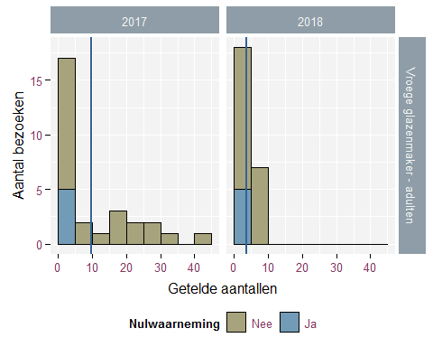

Figuur 3.2: Verdeling van totaal getelde aantallen per bezoek en het gemiddelde van de getelde aantallen (verticale lijn) - Vroege glazenmaker - adulten

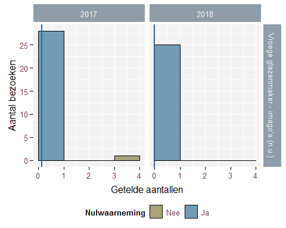

Figuur 3.2: Verdeling van totaal getelde aantallen per bezoek en het gemiddelde van de getelde aantallen (verticale lijn) - Vroege glazenmaker - imago’s (n.u.)

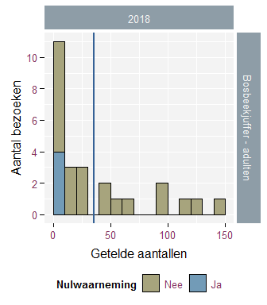

Figuur 3.3: Verdeling van de getelde aantallen per bezoek en het gemiddelde van de getelde aantallen (verticale lijn) - Bosbeekjuffer - adulten

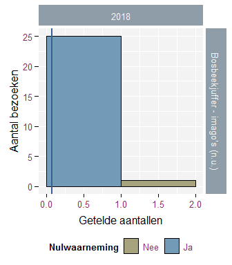

Figuur 3.3: Verdeling van de getelde aantallen per bezoek en het gemiddelde van de getelde aantallen (verticale lijn) - Bosbeekjuffer - imago’s (n.u.)

#### 3.3.1.2 Evolutie getelde aantallen binnen telperiode

Onderstaande figuren geven de evolutie van de getelde aantallen binnen het seizoen. De stippelijnen verbinden tellingen van eenzelfde locatie. De blauwe lijn toont de gemiddelde evolutie binnen het seizoen, waarbij de grijze banden aan beide kanten van de blauwe lijn de onzekerheid aangeven op deze gemiddelde evolutie.

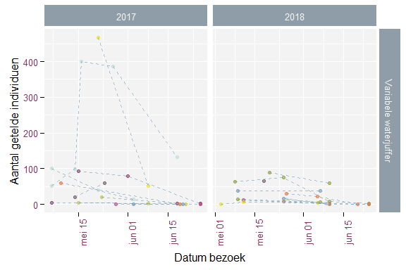

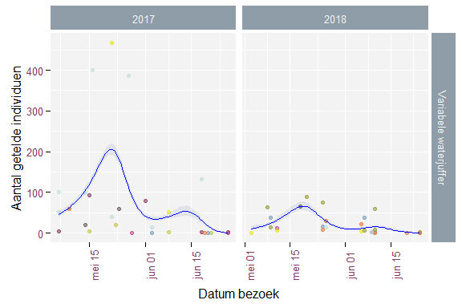

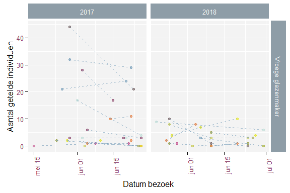

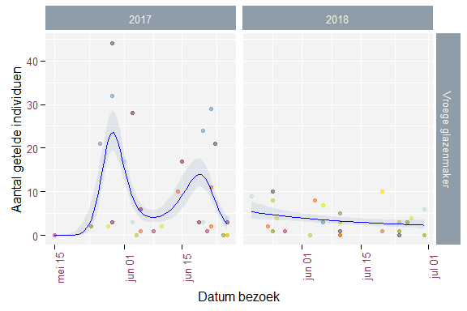

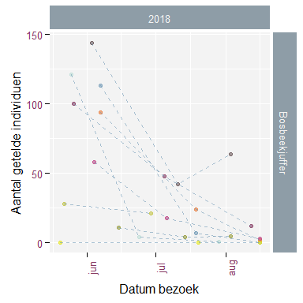

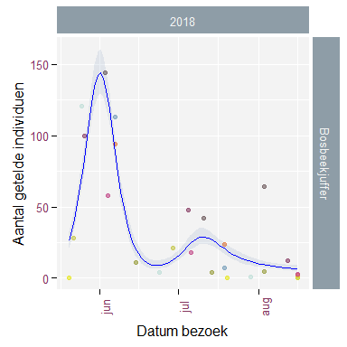

#### 3.3.1.3 Evolutie gemiddelde aantallen per locatie en per jaar

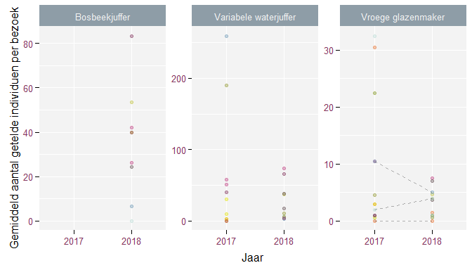

Figuur 3.4: Gemiddeld aantal getelde individuen per locatie en per jaar

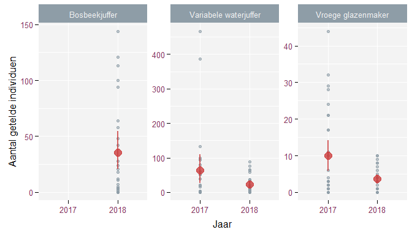

Figuur 3.5: Gemiddeld aantal getelde individuen per jaar met 95%-betrouwbaarheidsinterval (rood) en aantal getelde individuen per bezoek (grijs)

### 3.3.2 Gebiedstellingen

#### 3.3.2.1 Verdeling getelde aantallen per bezoek

Onderstaande figuren tonen de verdeling van de getelde aantallen per bezoek.

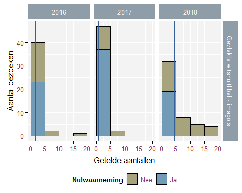

Figuur 3.6: Verdeling van totaal getelde aantallen per bezoek en het gemiddelde van de getelde aantallen (verticale lijn) - Gevlekte witsnuitlibel - imago’s

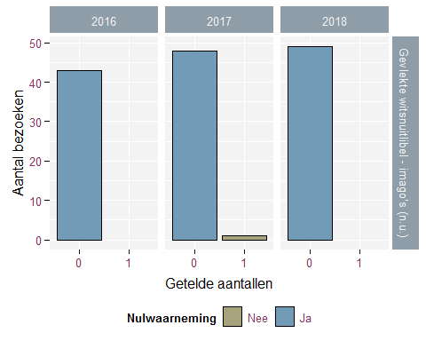

Figuur 3.6: Verdeling van totaal getelde aantallen per bezoek en het gemiddelde van de getelde aantallen (verticale lijn) - Gevlekte witsnuitlibel - imago’s (n.u.)

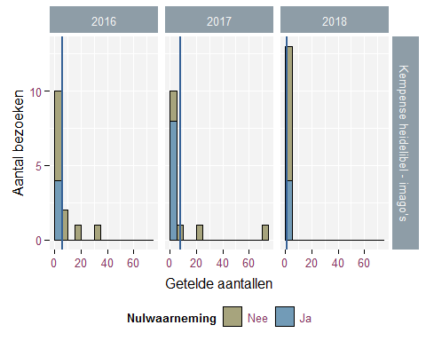

Figuur 3.6: Verdeling van totaal getelde aantallen per bezoek en het gemiddelde van de getelde aantallen (verticale lijn) - Kempense heidelibel - imago’s

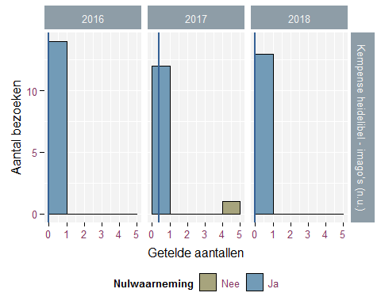

Figuur 3.6: Verdeling van totaal getelde aantallen per bezoek en het gemiddelde van de getelde aantallen (verticale lijn) - Kempense heidelibel - imago’s (n.u.)

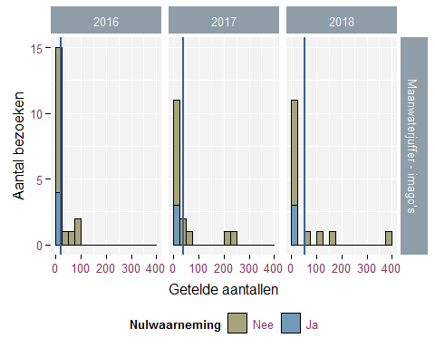

Figuur 3.6: Verdeling van totaal getelde aantallen per bezoek en het gemiddelde van de getelde aantallen (verticale lijn) - Maanwaterjuffer - imago’s

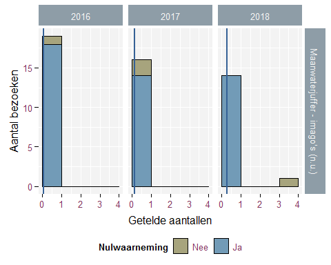

Figuur 3.6: Verdeling van totaal getelde aantallen per bezoek en het gemiddelde van de getelde aantallen (verticale lijn) - Maanwaterjuffer - imago’s (n.u.)

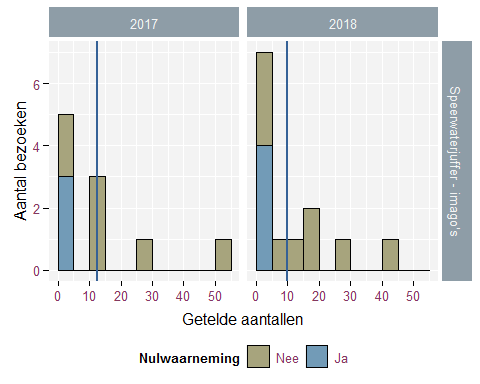

Figuur 3.6: Verdeling van totaal getelde aantallen per bezoek en het gemiddelde van de getelde aantallen (verticale lijn) - Speerwaterjuffer - imago’s

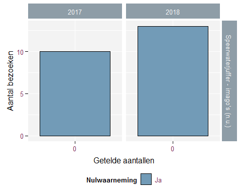

Figuur 3.6: Verdeling van totaal getelde aantallen per bezoek en het gemiddelde van de getelde aantallen (verticale lijn) - Speerwaterjuffer - imago’s (n.u.)

#### 3.3.2.2 Evolutie getelde aantallen binnen telperiode

Onderstaande figuren geven de evolutie van de getelde aantallen binnen het seizoen. De stippelijnen verbinden tellingen van eenzelfde locatie. De blauwe lijn toont de gemiddelde evolutie binnen het seizoen, waarbij de grijze banden aan beide kanten van de blauwe lijn de onzekerheid aangeven op deze gemiddelde evolutie.

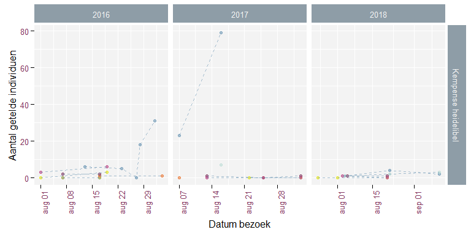

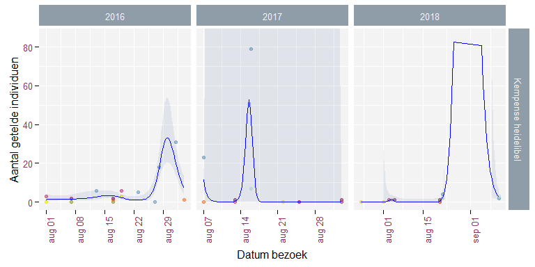

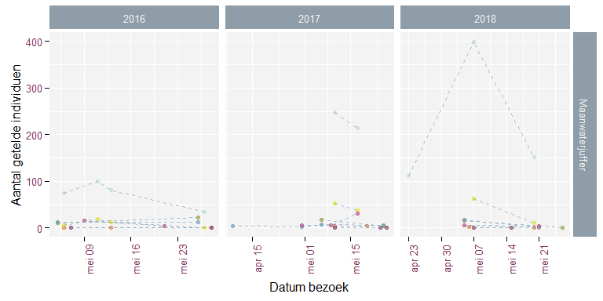

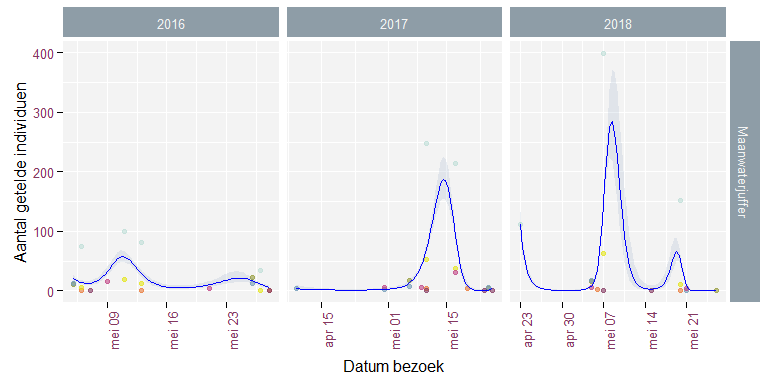

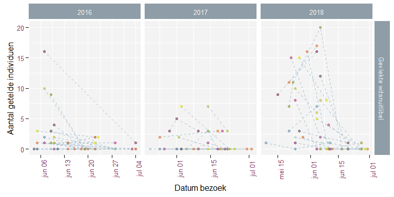

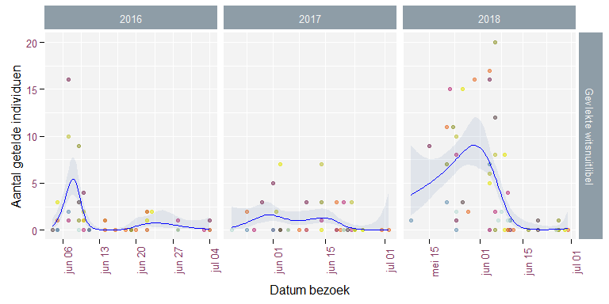

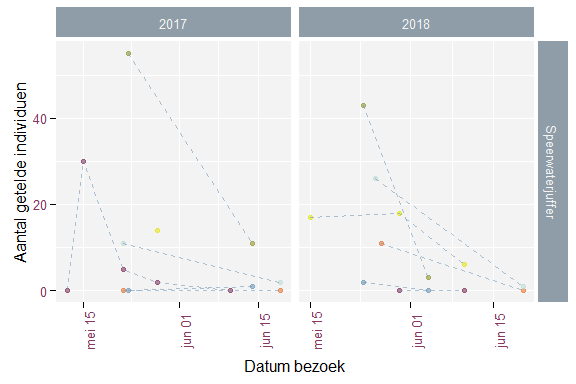

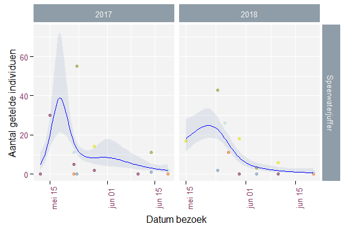

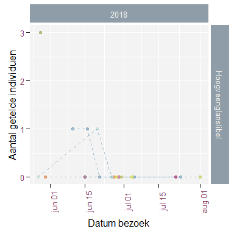

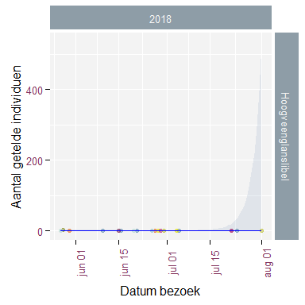

#### 3.3.2.3 Evolutie gemiddelde aantallen per locatie en per jaar

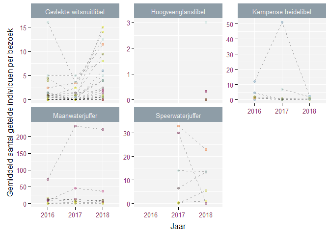

Figuur 3.7: Gemiddeld aantal getelde individuen per locatie en per jaar

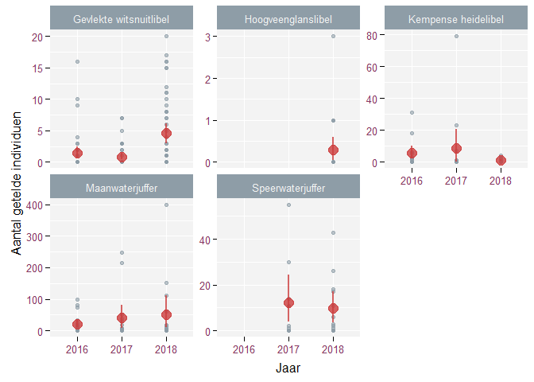

Figuur 3.8: Gemiddeld aantal getelde individuen per jaar met 95%-betrouwbaarheidsinterval (rood) en aantal getelde individuen per bezoek (grijs)

### 3.3.3 Telling larvenhuidjes

#### 3.3.3.1 Verdeling getelde aantallen per bezoek

Onderstaande figuren tonen de verdeling van de getelde aantallen per bezoek.

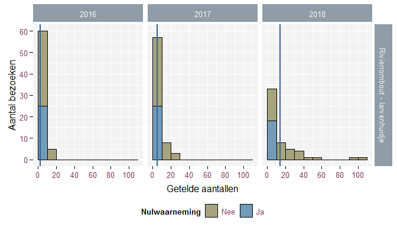

Figuur 3.9: Verdeling van het aantal getelde larvenhuidjes per bezoek en het gemiddelde aantal (verticale lijn) - Rivierrombout - larvenhuidje

#### 3.3.3.2 Evolutie getelde aantallen binnen telperiode

Onderstaande figuren geven de evolutie van de getelde aantallen binnen het seizoen. De stippelijnen verbinden tellingen van eenzelfde locatie. De blauwe lijn toont de gemiddelde evolutie binnen het seizoen, waarbij de grijze banden aan beide kanten van de blauwe lijn de onzekerheid aangeven op deze gemiddelde evolutie.

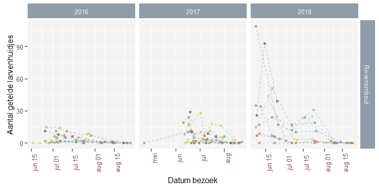

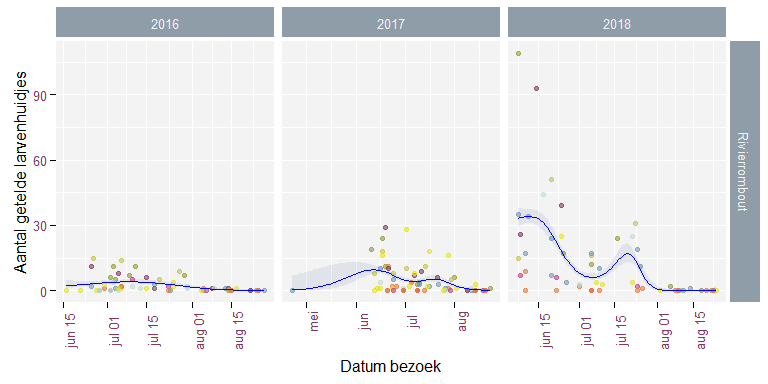

#### 3.3.3.3 Evolutie gemiddelde aantallen per locatie en per jaar

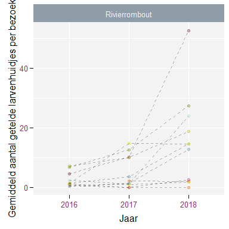

Figuur 3.10: Gemiddeld aantal getelde larvenhuidjes per locatie en per jaar

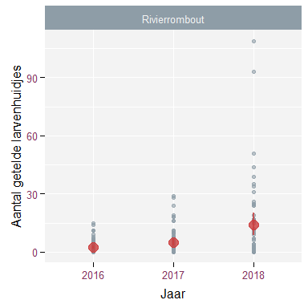

Figuur 3.11: Gemiddeld aantal getelde larvenhuidjes per jaar met 95%-betrouwbaarheidsinterval (rood) en aantal getelde larvenhuidjes per bezoek (grijs)

# 4 Vlinders

## 4.1 Meetnetkarakteristieken

Tabel 4.1 en Tabel 4.2 geven een overzicht van de karakteristieken van de vlindermeetnetten (Maes et al.2015).

Tabel 4.1: Overzicht van de karakteristieken van de vlindermeetnetten: veldprotocol, type meetnet (integraal of steekproef), aantal meetnetlocaties en de meetcyclus in jaren

| Meetnet | Protocol | Type | Meetnetlocaties | Meetcyclus (jaar) | Start |
| --- | --- | --- | --- | --- | --- |
| Aardbeivlinder | Vlinders - Transecten | Integraal | 4 | 1 | 2017 |
| Argusvlinder | Vlinders - Transecten | Steekproef | 30 | 3 | 2016 |
| Bruin dikkopje | Vlinders - Transecten | Integraal | 4 | 1 | 2017 |
| Bruine eikenpage | Vlinders - Gebiedstelling | Integraal | 13 | 1 | 2018 |
| Gentiaanblauwtje | Vlinders - Eitellingen | Integraal | 7 | 1 | 2016 |
| Grote weerschijnvlinder | Vlinders - Gebiedstelling | Integraal | 9 | 1 | 2018 |
| Heivlinder | Vlinders - Transecten | Steekproef | 30 | 3 | 2016 |
| Klaverblauwtje | Vlinders - Transecten | Integraal | 1 | 1 | 2017 |
| Kommavlinder | Vlinders - Transecten | Integraal | 12 | 1 | 2016 |
| Oranje zandoogje | Vlinders - Transecten | Steekproef | 60 | 3 | 2017 |
| Veldparelmoervlinder | Vlinders - Transecten | Integraal | 12 | 1 | 2016 |

Tabel 4.2: Overzicht van de karakteristieken van de vlindermeetnetten: aantal bezoeken per jaar, begin en einde van de telperiode

| Meetnet | Generatie | Bezoeken (/jaar) | Begin telperiode | Einde telperiode |
| --- | --- | --- | --- | --- |
| Aardbeivlinder |  | 3 | 1/mei | 31/mei |
| Argusvlinder | Generatie 1 | 3 | 1/mei | 31/mei |
|  | Generatie 2 | 3 | 20/jul | 20/aug |
| Bruin dikkopje | Generatie 1 | 3 | 1/mei | 31/mei |
|  | Generatie 2 | 3 | 20/jul | 20/aug |
| Bruine eikenpage |  | 1 | 1/dec | 30/mrt |
| Gentiaanblauwtje |  | 1 | 1/aug | 31/aug |
| Grote weerschijnvlinder |  | 3 | 1/jul | 30/jul |
| Heivlinder |  | 3 | 20/jul | 20/aug |
| Klaverblauwtje | Generatie 1 | 3 | 1/mei | 31/mei |
|  | Generatie 2 | 3 | 10/jul | 10/aug |
| Kommavlinder |  | 3 | 1/aug | 31/aug |
| Oranje zandoogje |  | 3 | 15/jul | 15/aug |
| Veldparelmoervlinder |  | 3 | 1/mei | 31/mei |

## 4.2 Overzicht van de uitgevoerde tellingen

### 4.2.1 Aantal tellingen en aantal getelde locaties

In bijlage 5.2 wordt per meetnetloctie een overzicht gegeven van de uitgevoerde taken.

Tabel 4.3 geeft een overzicht van de meetnetten waarvan de locaties jaarlijks worden geteld (de meetcyclus is dus 1 jaar). In de tabel onderscheiden we:

- de jaardoelen: het aantal te tellen locaties voor een bepaald jaar;
- het aantal tellingen conform protocol;
- het aantal tellingen dat niet kon worden uitgevoerd door overmacht; en
- het aantal voldoende getelde meetnetlocaties: dit zijn de locaties waar het aantal tellingen werd gehaald binnen de afgesproken telperiode, conform het protocol. Ook de tellingen die niet konden uitgevoerd worden door overmacht worden hiervoor meegrekend.

Tabel 4.3: Overzicht van de tellingen voor de vlindermeetnetten met 1-jarige meetcyclus en de vooropgestelde doelen

| Protocol | Meetnet | Jaar | Jaardoel | Tellingen conform protocol | Tellingen niet uitvoerbaar | Meetnetlocaties voldoende geteld - totaal |
| --- | --- | --- | --- | --- | --- | --- |
| Vlinders - Eitellingen | Bruine eikenpage | 2017 | 3 locaties | 7 | 0 | 7 |
|  | Gentiaanblauwtje | 2016 | 7 locaties | 16 | 0 | 14 |
|  |  | 2017 | 7 locaties | 16 | 0 | 16 |
|  |  | 2018 | 7 locaties | 17 | 0 | 17 |
| Vlinders - Gebiedstelling | Bruine eikenpage | 2018 | 7 locaties | 36 | 0 | 10 |
|  | Grote weerschijnvlinder | 2018 | 5 locaties | 22 | 0 | 7 |
| Vlinders - Transecten | Aardbeivlinder | 2017 | 4 locaties | 19 | 0 | 4 |
|  |  | 2018 | 4 locaties | 23 | 0 | 4 |
|  | Bruin dikkopje | 2017 | 3 locaties | 22 | 0 | 3 |
|  |  | 2018 | 4 locaties | 20 | 0 | 2 |
|  | Klaverblauwtje | 2017 | 1 locaties | 6 | 0 | 1 |
|  |  | 2018 | 1 locaties | 5 | 0 | 0 |
|  | Kommavlinder | 2016 | 10 locaties | 29 | 3 | 10 |
|  |  | 2017 | 10 locaties | 26 | 3 | 8 |
|  |  | 2018 | 10 locaties | 37 | 0 | 10 |
|  | Veldparelmoervlinder | 2016 | 10 locaties | 31 | 0 | 9 |
|  |  | 2017 | 10 locaties | 32 | 3 | 9 |
|  |  | 2018 | 10 locaties | 34 | 0 | 10 |

Tabel 4.4 geeft een overzicht van de meetnetten met een meetcyclus van 3 jaar. De tabel geeft volgende bijkomende informatie:

- de doelen voor de meetcyclus: het aantal te tellen locaties voor de volledige meetcyclus;
- de nieuwe getelde meetnetlocaties: de locaties die voor een eerste maal (voldoende) werden geteld binnen de meetcyclus;
- het totaal aantal getelde locaties binnen een meetcyclus.

Tabel 4.4: Overzicht van de tellingen voor de vlindermeetnetten met 3-jarige meetcyclus en de vooropgestelde doelen

| Protocol | Meetnet | Jaar | Jaardoel | Doel meetcyclus | Tellingen conform protocol | Tellingen niet uitvoerbaar | Meetnetlocaties voldoende geteld - totaal | Meetnetlocaties voldoende geteld - nieuw | Meetnetlocaties voldoende geteld - cyclus |
| --- | --- | --- | --- | --- | --- | --- | --- | --- | --- |
| Vlinders - Transecten | Argusvlinder | 2016 | 10 locaties | 30 locaties | 98 | 0 | 15 | 15 | 31 |
|  |  | 2017 | 6 nieuwe locaties | 30 locaties | 80 | 0 | 13 | 11 | 31 |
|  |  | 2018 | 6 nieuwe locaties | 30 locaties | 52 | 0 | 8 | 5 | 31 |
|  | Heivlinder | 2016 | 10 locaties | 30 locaties | 69 | 0 | 18 | 18 | 29 |
|  |  | 2017 | 6 nieuwe locaties | 30 locaties | 23 | 0 | 6 | 3 | 29 |
|  |  | 2018 | 6 nieuwe locaties | 30 locaties | 34 | 0 | 9 | 8 | 29 |
|  | Oranje zandoogje | 2017 | 12 nieuwe locaties | 30 locaties | 46 | 0 | 12 | 12 | 21 |
|  |  | 2018 | 6 nieuwe locaties | 30 locaties | 33 | 0 | 10 | 9 | 21 |

### 4.2.2 Tijdstippen van de tellingen

Figuur 4.1 geeft een overzicht van de tijdstippen van de bezoeken.

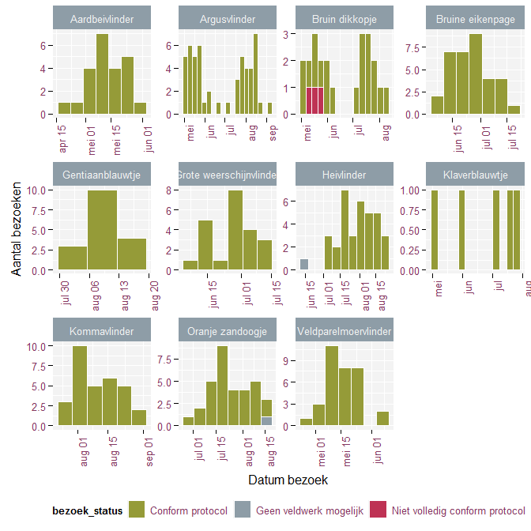

Figuur 4.1: Overzicht tijdstippen waarop tellingen werden uitgevoerd in 2018

### 4.2.3 Afwijkingen van het protocol

De volgende tabel geeft een overzicht van de afwijkingen van het protocol.

| meetnet | datum | locatie | bezoek status | opmerkingen |
| --- | --- | --- | --- | --- |
| Bruin dikkopje | 2018-05-09 | Tiendeberg | Niet volledig conform protocol | Waarnemingen door Michiel De Koster. Niet alle secties geteld. |
| Bruin dikkopje | 2018-05-15 | Tiendeberg | Niet volledig conform protocol | Waarnemer Michiel De Koster - Niet alle secties geteld |
| Bruin dikkopje | 2018-05-21 | Tiendeberg | Niet volledig conform protocol | Waarnemer Michiel De Koster - Niet alle secties geteld |
| Heivlinder | 2018-06-13 | Maatheide | Geen veldwerk mogelijk | Geen toestemming verleend voor het betreden van Maatheide. (o.a. ref. mail Wim Verachtert) |
| Oranje zandoogje | 2018-08-16 | Strijpen (UTM1km-hok ES5535) | Geen veldwerk mogelijk | Berm gemaaid |

## 4.3 Verkenning van de ingevoerde aantallen

### 4.3.1 Transecttellingen

#### 4.3.1.1 Aantal getelde secties per transect

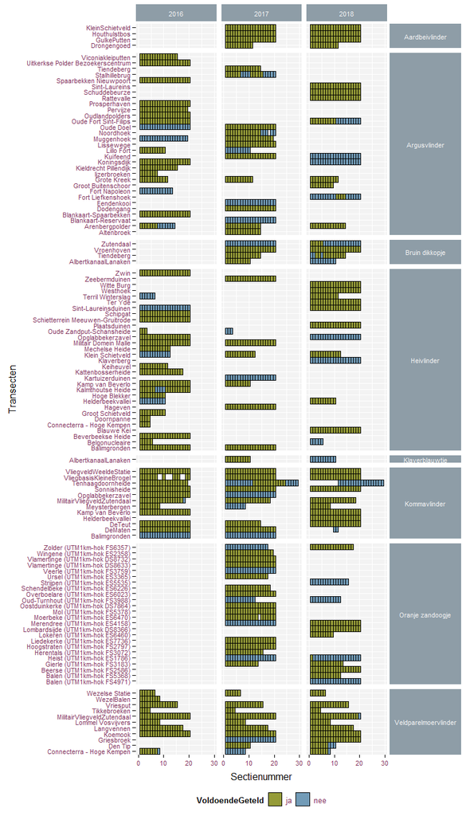

Figuur 4.2: Aantal tellingen per sectie en per jaar voor de verschillende vlindertransecten

#### 4.3.1.2 Verdeling totale aantallen per bezoek

Onderstaande figuren tonen de verdeling van de getelde aantallen per bezoek. Voor de transecttellingen gaat het over het totaal getelde aantal per bezoek over alle secties van het transect.

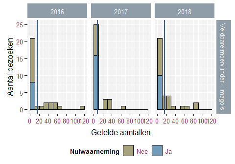

Figuur 4.3: Verdeling van totaal getelde aantallen per bezoek en het gemiddelde van de getelde aantallen (verticale lijn) - Veldparelmoervlinder

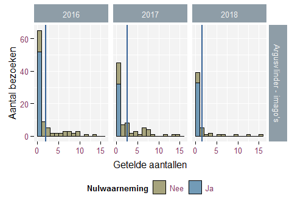

Figuur 4.3: Verdeling van totaal getelde aantallen per bezoek en het gemiddelde van de getelde aantallen (verticale lijn) - Argusvlinder

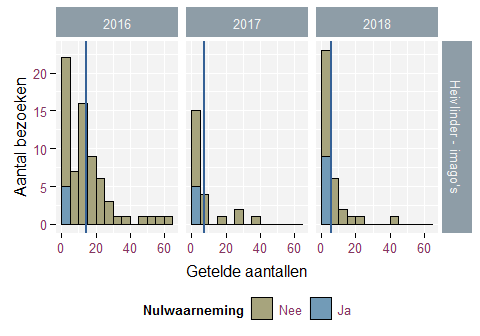

Figuur 4.3: Verdeling van totaal getelde aantallen per bezoek en het gemiddelde van de getelde aantallen (verticale lijn) - Heivlinder

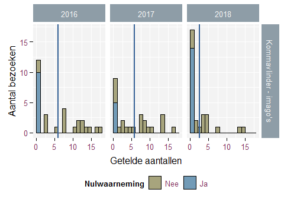

Figuur 4.3: Verdeling van totaal getelde aantallen per bezoek en het gemiddelde van de getelde aantallen (verticale lijn) - Kommavlinder

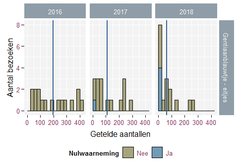

Figuur 4.3: Verdeling van totaal getelde aantallen per bezoek en het gemiddelde van de getelde aantallen (verticale lijn) - Gentiaanblauwtje

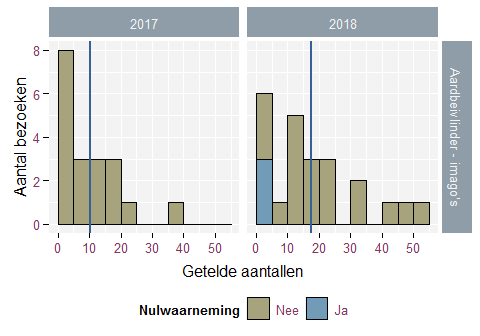

Figuur 4.3: Verdeling van totaal getelde aantallen per bezoek en het gemiddelde van de getelde aantallen (verticale lijn) - Aardbeivlinder

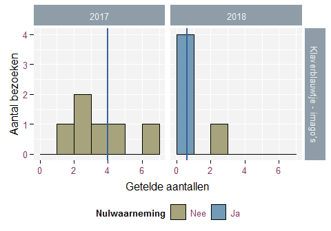

Figuur 4.3: Verdeling van totaal getelde aantallen per bezoek en het gemiddelde van de getelde aantallen (verticale lijn) - Klaverblauwtje

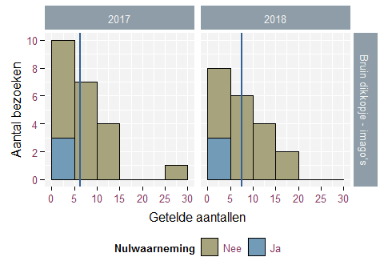

Figuur 4.3: Verdeling van totaal getelde aantallen per bezoek en het gemiddelde van de getelde aantallen (verticale lijn) - Bruin dikkopje

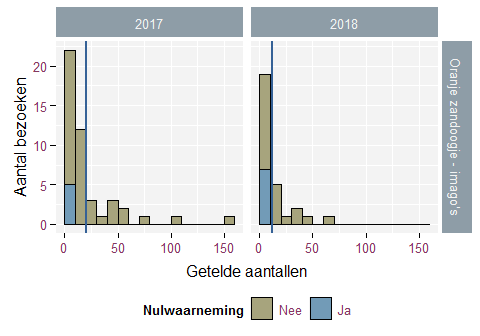

Figuur 4.3: Verdeling van totaal getelde aantallen per bezoek en het gemiddelde van de getelde aantallen (verticale lijn) - Oranje zandoogje

#### 4.3.1.3 Evolutie getelde aantallen binnen telperiode

Onderstaande figuren geven de evolutie van de getelde aantallen binnen het seizoen. De stippelijnen verbinden tellingen van eenzelfde locatie. De blauwe lijn toont de gemiddelde evolutie binnen het seizoen, waarbij de grijze banden aan beide kanten van de blauwe lijn de onzekerheid aangeven op deze gemiddelde evolutie.

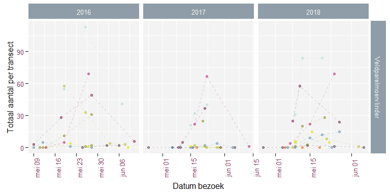

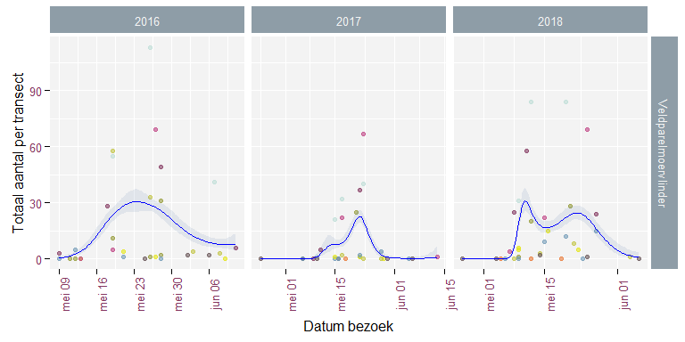

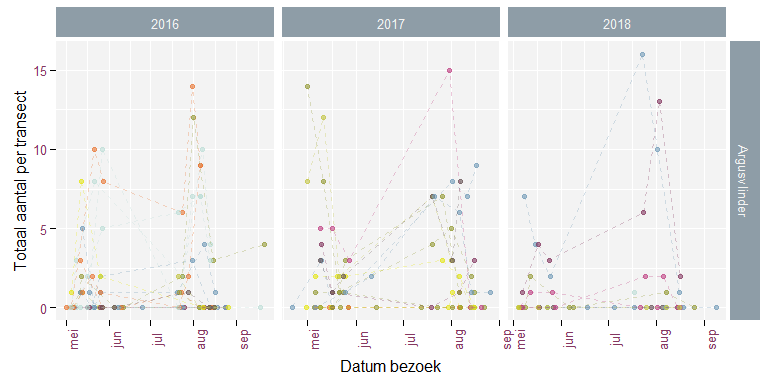

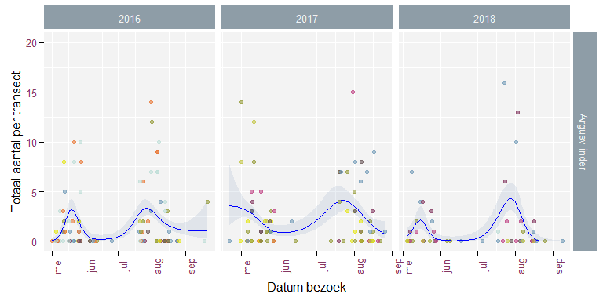

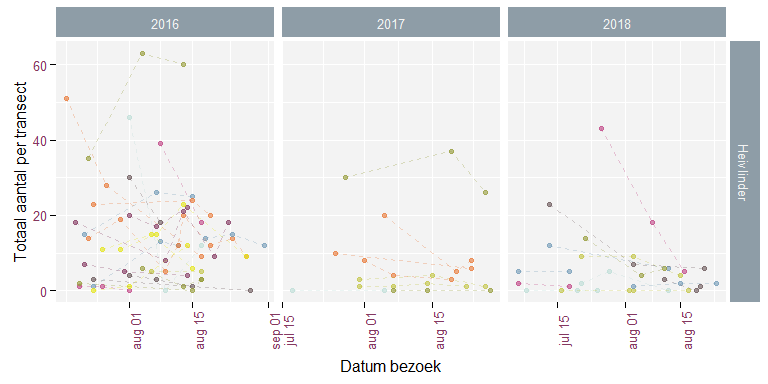

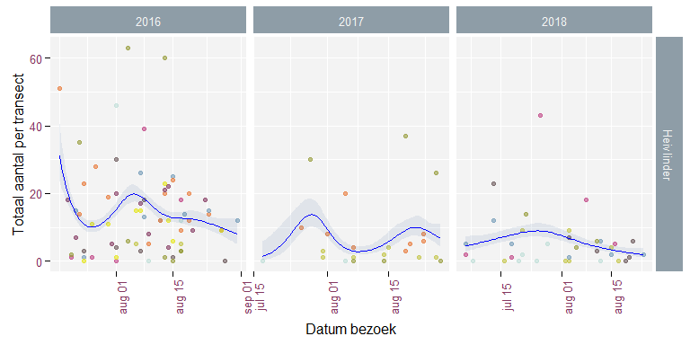

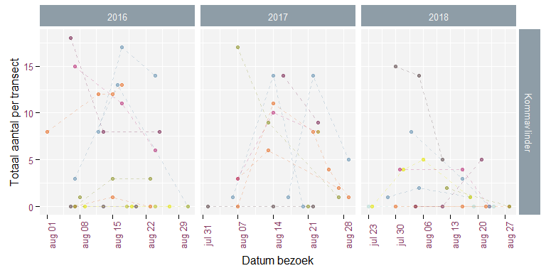

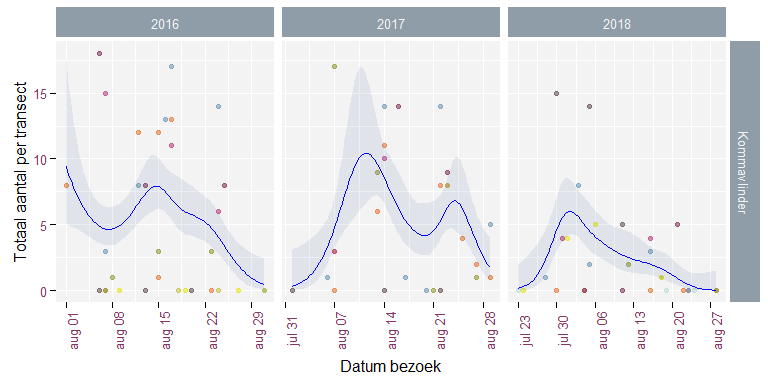

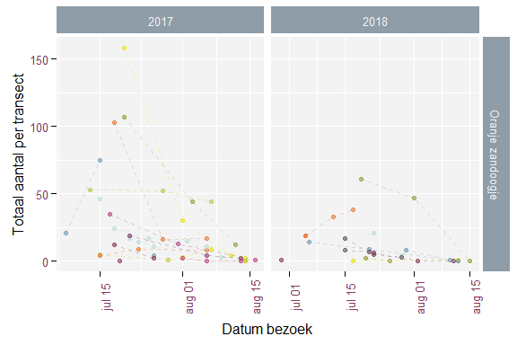

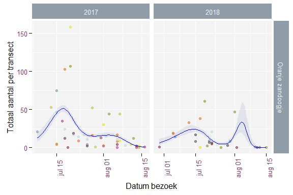

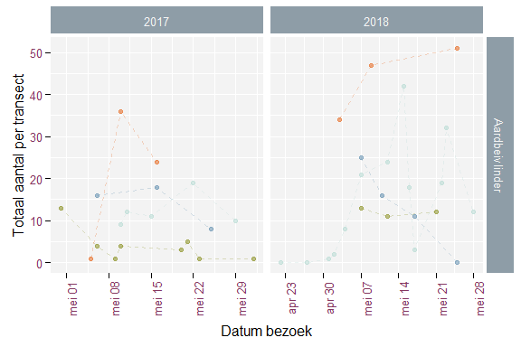

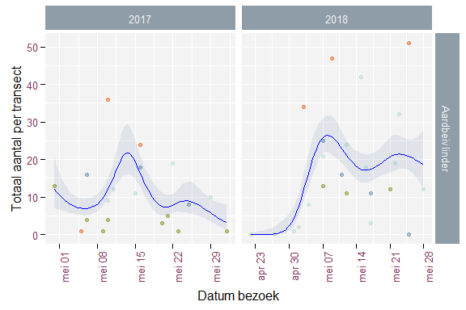

[3 more figures not shown]